Wirtschafts- und Sozialwissenschaftliche Fakultät Institut für Erziehungswissenschaft

# Clusteranalyse der Item-Reliabilität

Reproducible Report der Analysen.

Autor Prof. Dr. Samuel Merk

Datum 8. Oktober 2026

## Libraries

Zentrale Bibliotheken für die Analysen und Visualisierungen werden geladen. Die Farbpalette `ut_palette` ist an das Corporate Design der Universität angepasst.

```r
library(ggplot2)
library(readxl)
library(dplyr)
library(readr)
library(stringr)
library(cluster)
library(pheatmap)
library(tinytable)

ut_palette <- c(
  karminrot = "#A51E37",
  mattgold = "#B4A069",
  anthrazit = "#32414B",
  blau = "#0069AA",
  hellblau = "#50AAC8",
  violett = "#AF6E96",
  ziegel = "#C8503C",
  ocker = "#D29600"
)
scale_colour_ut <- function(...) {
  scale_colour_manual(values = unname(ut_palette), ...)
}
scale_fill_ut <- function(...) {
  scale_fill_manual(values = unname(ut_palette), ...)
}
```

## Daten

Die DAten habe ich als Excel-Datei in `data/IRR_data.xlsx` bekommen. Sie enthält die Item-Kennwerte, die im Rahmen der Reliabilitätsanalyse berechnet wurden.

```r
IRR_data <- read_excel("data/IRR_data.xlsx")
```

## Abgeleitete Variablen

Die Variable `Item_beschreibung` enthält im Prinzip mehrere Variablen, die für die Clusteranalyse getrennt relevant sein könnten sind. Daher werden sie inzwei neue Variablen getrennt:

- `zahl` enthält die Zahl, um die es im Item geht. Bei „Zahlzerlegung nutzen“-Items ist das bei Subtraktionen der Minuend und bei Additionen die Summe (z.B. „4 + 6“ → 10).
- `aufgabenform` beschreibt die Art des Items.

Wie sinnvoll das ist oder inwiefern das anders geschehen sollte kann a priori aus fachdidaktischer Expertise heraus entschieden werden oder post-hoc anhand der Ergebnisse.

```r
IRR_data <- IRR_data |>
  mutate(
    aufgabenform = case_when(
      str_detect(item_beschreibung, "Streifen linear") ~ "Streifen linear",
      str_detect(item_beschreibung, "Blockdarstellung") ~ "Blockdarstellung",
      str_detect(item_beschreibung, "Streifen") ~ "Streifen",
      str_detect(item_beschreibung, "Freund") ~ "Freund",
      str_detect(item_beschreibung, "nutzen") ~ "Zahlzerlegung nutzen"
    ),
    zahlen = str_extract_all(item_beschreibung, "\\d+") |> lapply(as.integer),
    zahl = case_when(
      aufgabenform == "Zahlzerlegung nutzen" &
        str_detect(item_beschreibung, "\\+") ~
        vapply(zahlen, sum, integer(1)),
      .default = vapply(zahlen, \(x) x[1], integer(1))
    )
  ) |>
  select(-zahlen)

tt(IRR_data) |>
  theme_html(
    engine = "tabulator",
    tabulator_search = "top",
    tabulator_pagination = TRUE
  )
```

## Clustered Heatmap

Das Ergebnis ist eine Distanzmatrix (aller Items) zwischen 0 (identisch) und 1 (maximal verschieden), in der keine Variable aufgrund ihrer Maßeinheit überproportional gewichtet ist.

Dann werden Zeilen mit **Average Linkage** geclustert. Bei jedem Schritt werden zwei Gruppen zusammengeführt, zwischen denen der *durchschnittliche* Abstand aller Item-Paare – eines aus der einen, eines aus der anderen Gruppe – am kleinsten ist. Im Gegensatz zur Single Linkage (nur das nächste Paar) ist Average Linkage weniger anfällig für Ketteneffekte, im Gegensatz zur Complete Linkage (nur das weiteste Paar) weniger sensitiv für Ausreißer. Die Wahl ist sinnvoll, da die Gower-Distanz keine echten euklidischen Abstände erzeugt.

Hinweis: Zwei der sechs Variablen sind kategorial und gehen nur als gleich/verschieden ein. Sie haben daher ein relativ hohes Gewicht in der Distanz.

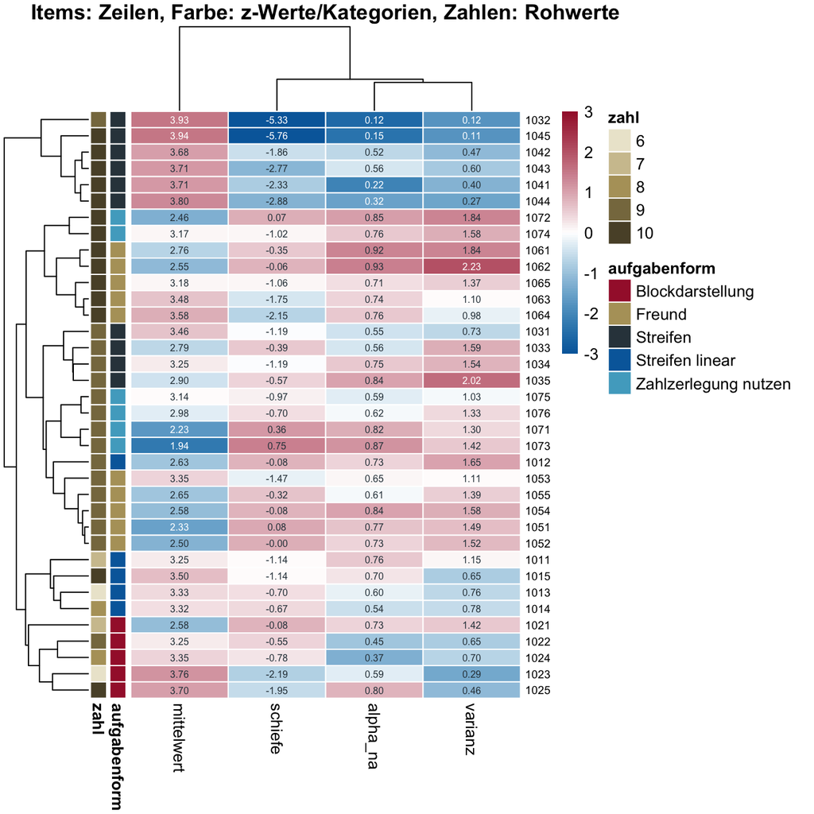

```r
heat_df <- IRR_data |>
  mutate(aufgabenform = factor(aufgabenform), zahl = factor(zahl)) |>
  select(item_kuerzel, aufgabenform, zahl, alpha_na, schiefe, varianz, mittelwert) |>
  as.data.frame()
rownames(heat_df) <- heat_df$item_kuerzel

gower_dist <- daisy(heat_df[, -1], metric = "gower")
row_clust <- hclust(gower_dist, method = "average")

heat_mat <- scale(as.matrix(heat_df[, c("alpha_na", "schiefe", "varianz", "mittelwert")]))

# Raw (unstandardised) values as cell labels; colour shows z-values
raw_mat <- as.matrix(heat_df[, colnames(heat_mat)])
cell_labels <- matrix(sprintf("%.2f", raw_mat), nrow(raw_mat), dimnames = dimnames(raw_mat))

col_clust <- hclust(dist(t(heat_mat)), method = "average")

# CD colours: diverging blau – weiß – karminrot for z-values
heat_colors <- colorRampPalette(c(ut_palette[["blau"]], "white", ut_palette[["karminrot"]]))(100)

# Per-cell text colour (white on dark cells). pheatmap draws labels column-wise
# in clustered order, so the vector must follow that order.
text_col <- ifelse(abs(heat_mat) > 1.5, "white", ut_palette[["anthrazit"]])
number_colors <- as.vector(text_col[row_clust$order, col_clust$order])

# Categorical: CD palette; zahl is ordinal, so a light-to-dark gold ramp
anno_colors <- list(
  aufgabenform = setNames(unname(ut_palette)[seq_len(nlevels(heat_df$aufgabenform))], levels(heat_df$aufgabenform)),
  zahl = setNames(colorRampPalette(c("#ECE6D2", ut_palette[["mattgold"]], "#5A5034"))(nlevels(heat_df$zahl)), levels(heat_df$zahl))
)

pheatmap(
  heat_mat,
  cluster_rows = row_clust,
  cluster_cols = col_clust,
  annotation_row = heat_df[c("aufgabenform", "zahl")],
  annotation_colors = anno_colors,
  color = heat_colors,
  breaks = seq(-3, 3, length.out = 101),
  display_numbers = cell_labels,
  number_color = number_colors,
  border_color = "white",
  fontsize_number = 6,
  fontsize_row = 7,
  main = "Items: Zeilen, Farbe: z-Werte/Kategorien, Zahlen: Rohwerte"
)
```

## Heatmap mit dichotomisiertem Krippendorff-Alpha

Alpha (`alpha_na`) ist das nach Krippendorff (2018) berechnete Agreement des Items. Ein Wert von 0,6 wird in der psychometrischen Praxis häufig als Minimalgrenze für zuverlässige Items herangezogen. Daher wird wird als nächstes `alpha_na` nochmals als dichotome Variable behandelt:

- **Kategorie ≤ 0,6:** Items mit geringerer Zuverlässigkeit
- **Kategorie > 0,6:** Items mit höherer Zuverlässigkeit

In der Gower-Distanz geht diese dichotome Variable damit als nominale Kategorie ein (gleich vs. verschieden) und erhält denselben Beitrag wie `aufgabenform` und `zahl`.

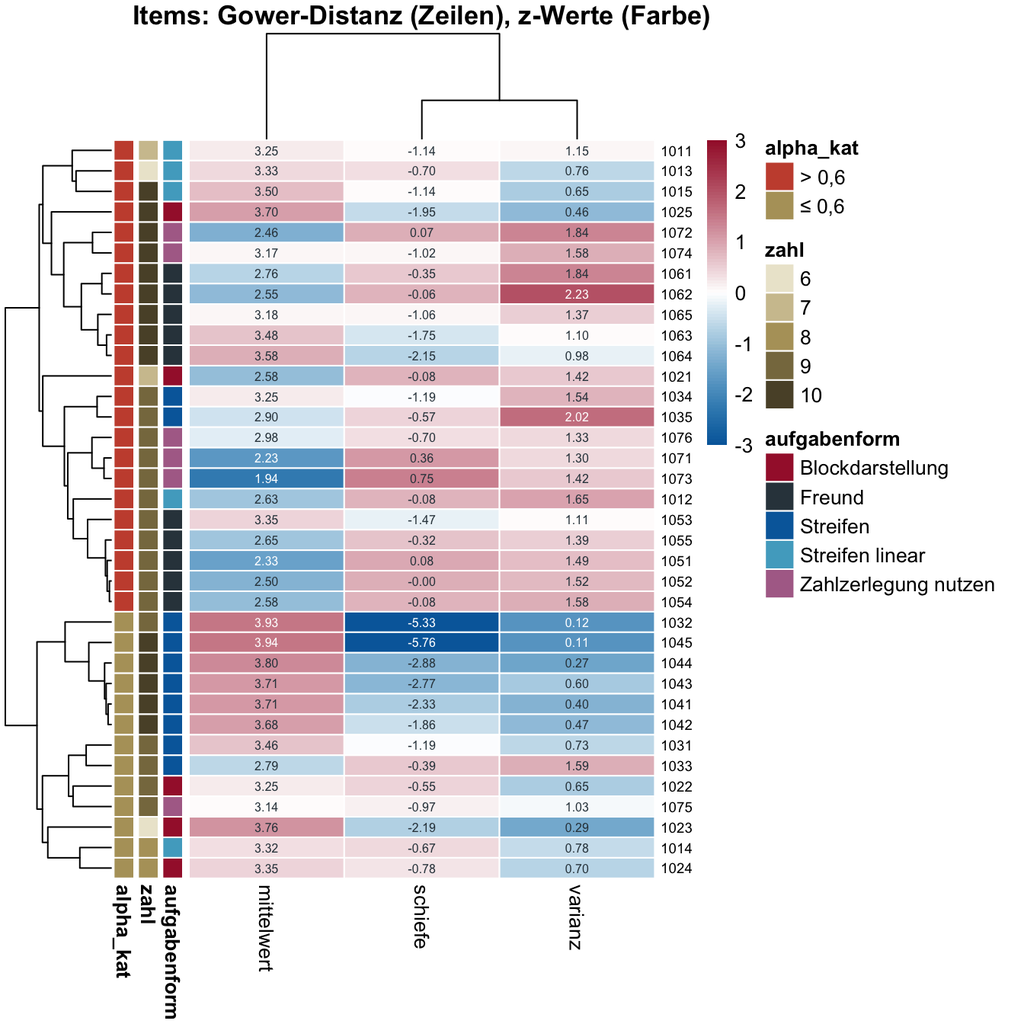

```r
heat_df2 <- IRR_data |>
  mutate(
    aufgabenform = factor(aufgabenform),
    zahl = factor(zahl),
    alpha_kat = if_else(alpha_na > 0.6, "> 0,6", "≤ 0,6") |> factor()
  ) |>
  select(item_kuerzel, aufgabenform, zahl, alpha_kat, schiefe, varianz, mittelwert) |>
  as.data.frame()
rownames(heat_df2) <- heat_df2$item_kuerzel

gower_dist2 <- daisy(heat_df2[, -1], metric = "gower")
row_clust2 <- hclust(gower_dist2, method = "average")

heat_mat2 <- scale(as.matrix(heat_df2[, c("schiefe", "varianz", "mittelwert")]))

# Raw (unstandardised) values as cell labels; colour shows z-values
raw_mat2 <- as.matrix(heat_df2[, colnames(heat_mat2)])
cell_labels2 <- matrix(sprintf("%.2f", raw_mat2), nrow(raw_mat2), dimnames = dimnames(raw_mat2))

col_clust2 <- hclust(dist(t(heat_mat2)), method = "average")

# CD colours: diverging blau – weiss – karminrot for z-values
heat_colors2 <- colorRampPalette(c(ut_palette[["blau"]], "white", ut_palette[["karminrot"]]))(100)

# Per-cell text colour (white on dark cells). pheatmap draws labels column-wise
# in clustered order, so the vector must follow that order.
text_col2 <- ifelse(abs(heat_mat2) > 1.5, "white", ut_palette[["anthrazit"]])
number_colors2 <- as.vector(text_col2[row_clust2$order, col_clust2$order])

# Categorical: CD palette without mattgold (reserved for the ordinal zahl ramp);
# alpha_kat uses karminrot/mattgold to signal the dichotomy
anno_colors2 <- list(
  aufgabenform = setNames(unname(ut_palette[names(ut_palette) != "mattgold"])[seq_len(nlevels(heat_df2$aufgabenform))], levels(heat_df2$aufgabenform)),
  zahl = setNames(colorRampPalette(c("#ECE6D2", ut_palette[["mattgold"]], "#5A5034"))(nlevels(heat_df2$zahl)), levels(heat_df2$zahl)),
  alpha_kat = setNames(c("#C8503C", "#B4A069"), c("> 0,6", "≤ 0,6"))
)

pheatmap(
  heat_mat2,
  cluster_rows = row_clust2,
  cluster_cols = col_clust2,
  annotation_row = heat_df2[c("aufgabenform", "zahl", "alpha_kat")],
  annotation_colors = anno_colors2,
  color = heat_colors2,
  breaks = seq(-3, 3, length.out = 101),
  display_numbers = cell_labels2,
  number_color = number_colors2,
  border_color = "white",
  fontsize_number = 6,
  fontsize_row = 7,
  main = "Items: Gower-Distanz (Zeilen), z-Werte (Farbe)"
)
```